# Processing evaluation RMassBank

## 3751 Caprolactam

mz = 114.0913 (OK)

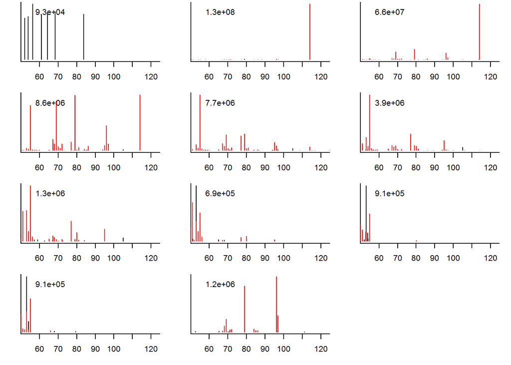

## 4146 Triacetonamin

mz = 156.1383 (OK)

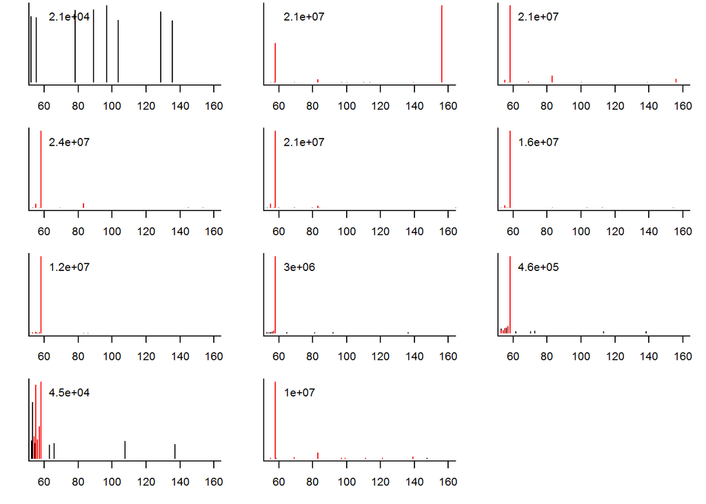

## 4148 4-Trifluormethylanilin

mz = 162.0525 (OK)

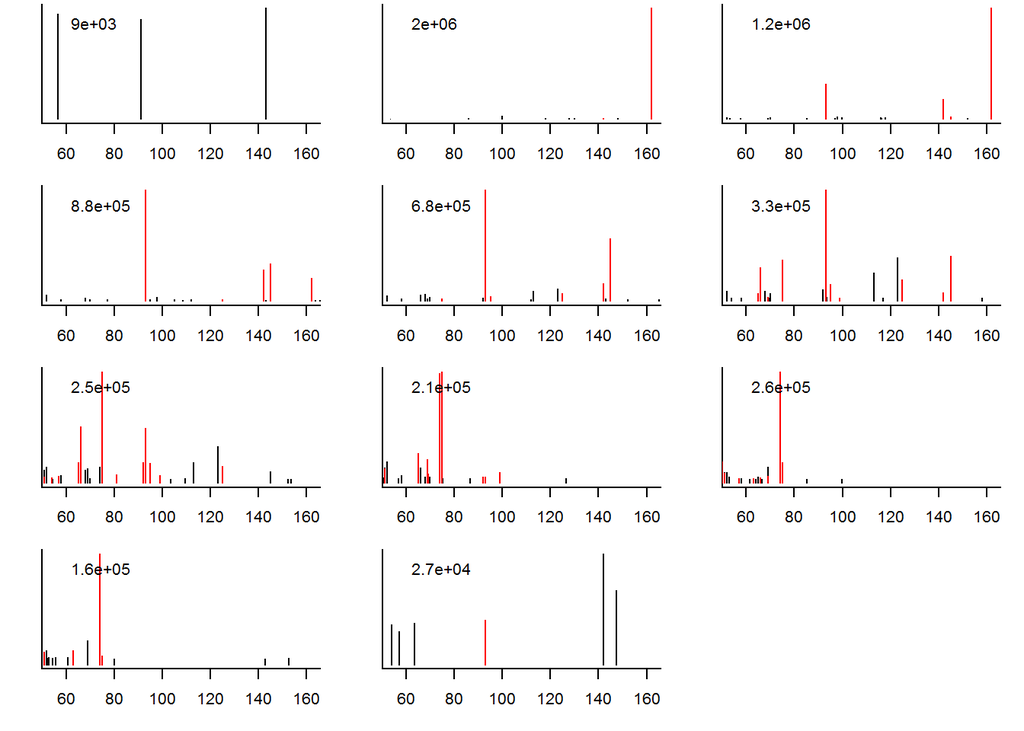

## 4153 2-[(dimethylamino)methyl]benzonitrile

mz = 161.1073 (OK)

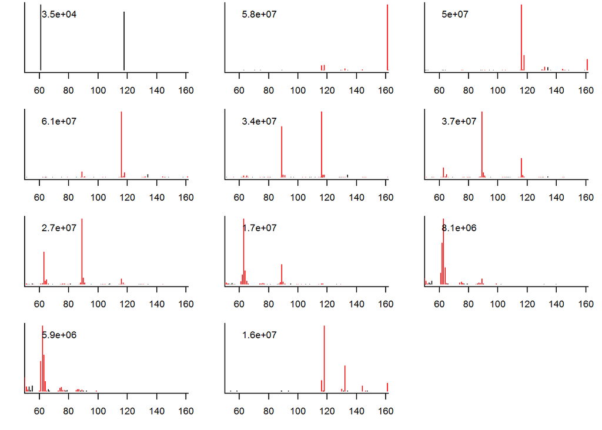

## 4151 Tolylbenzonitril

mz = 194.0964 (OK)

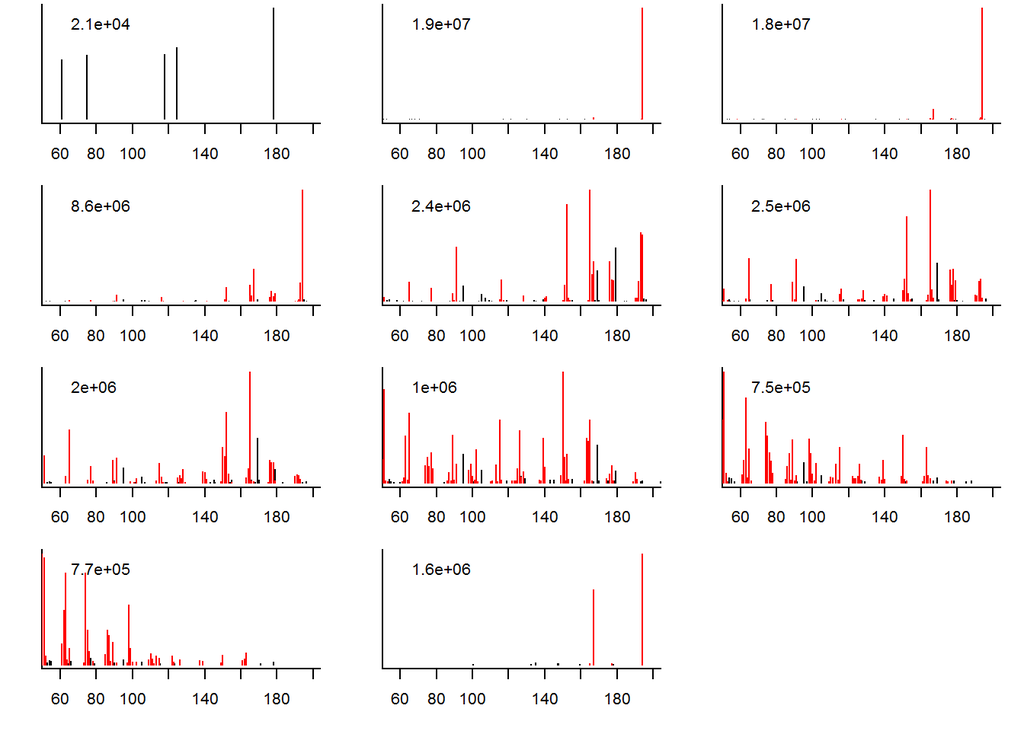

## 4152 5-Bromo-2-methoxyphenol

mz = (not found)

## 4194 Tribenoside

mz = 479.2428 (OK)

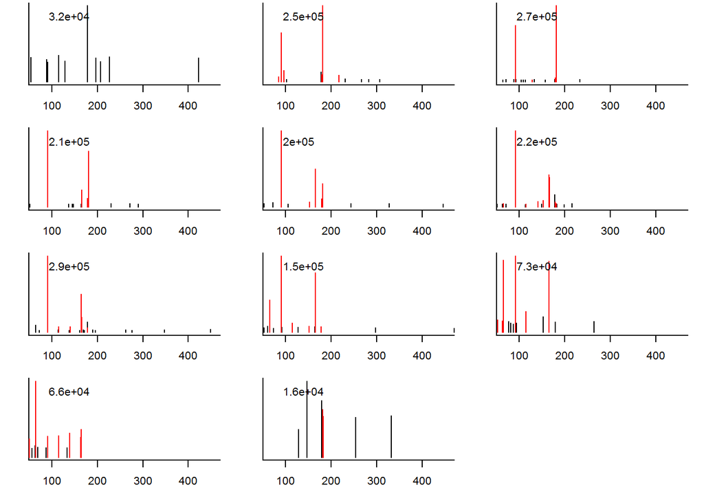

## 4131 Acitretin

mz = 327.1955 (OK)

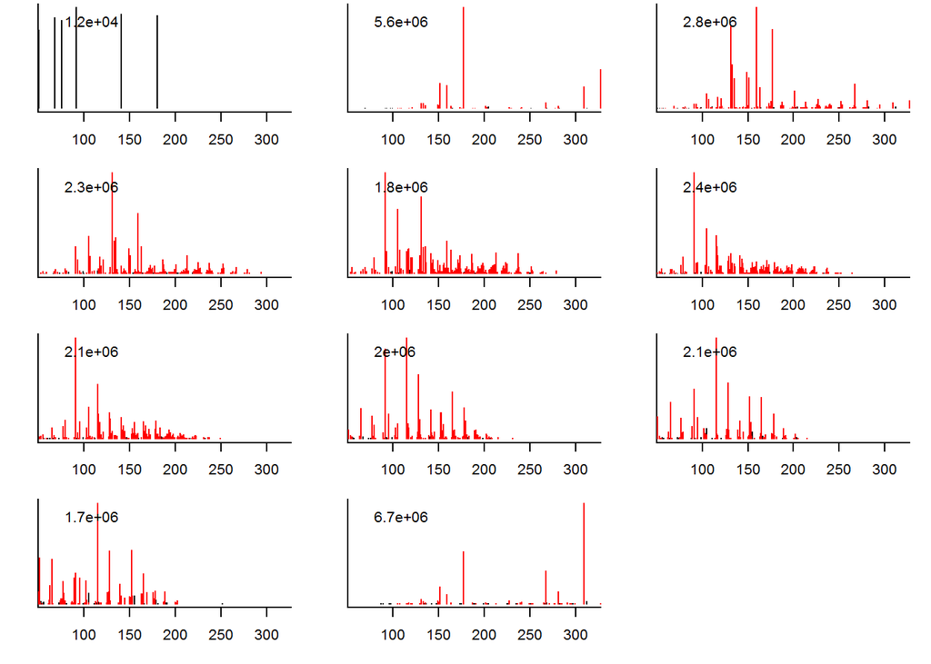

## 4136 Fosfomycin trometamol

mz = (not found)

## 4137 Meloxicam

mz = 352.042 (OK)

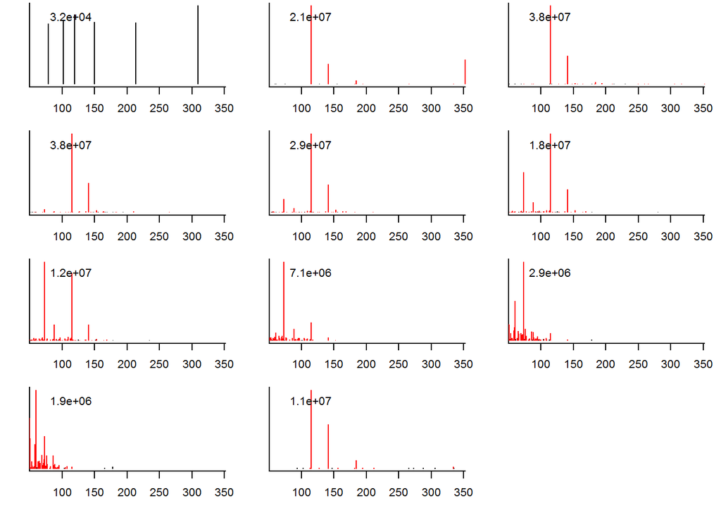

## 4127 Aceclofenac

mz = 354.0294 (OK)

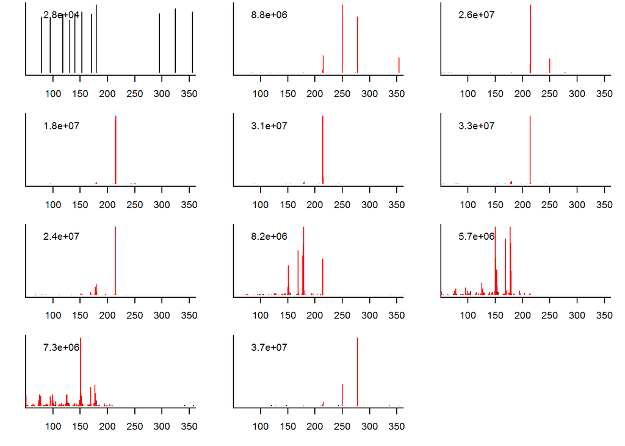

## 4139 Tranexamic acid

mz = 158.1176 (OK)

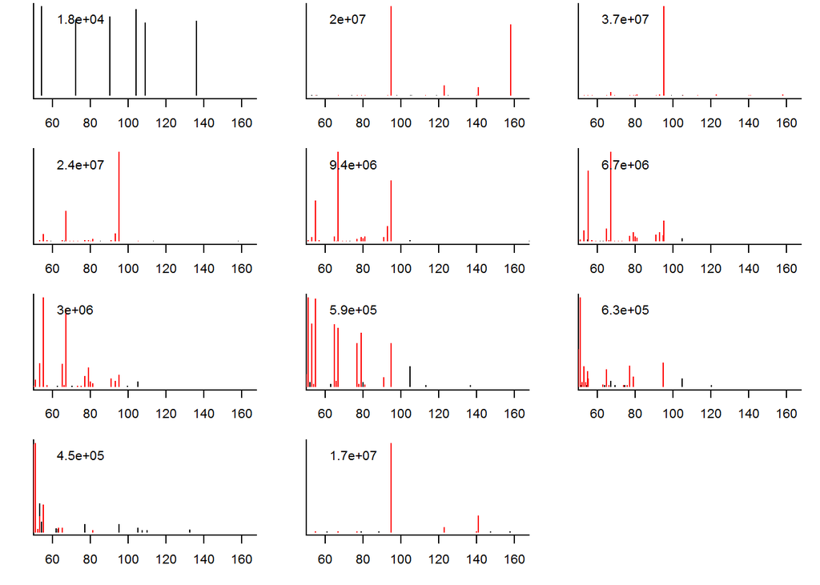

## 4134 Lacidipine

mz = 456.2381 (OK)

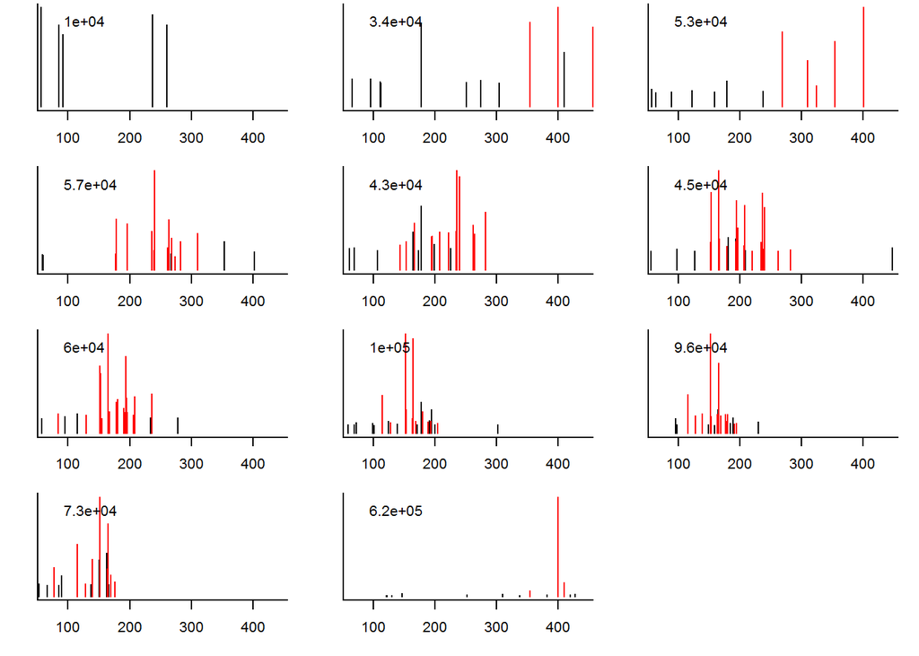

## 4133 Nefopam

mz = 254.1539 (OK)

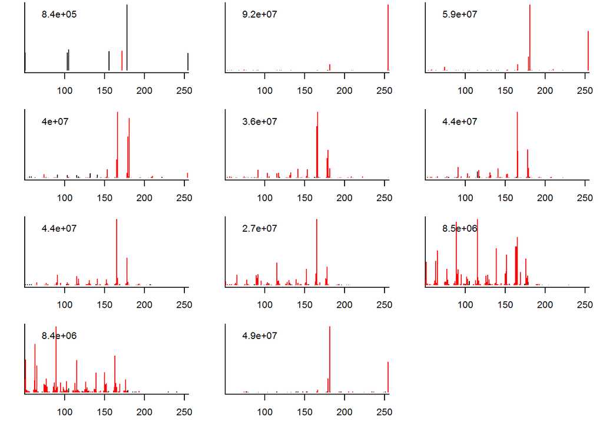

## 4130 Nicorandil

mz = 212.0666 (OK)

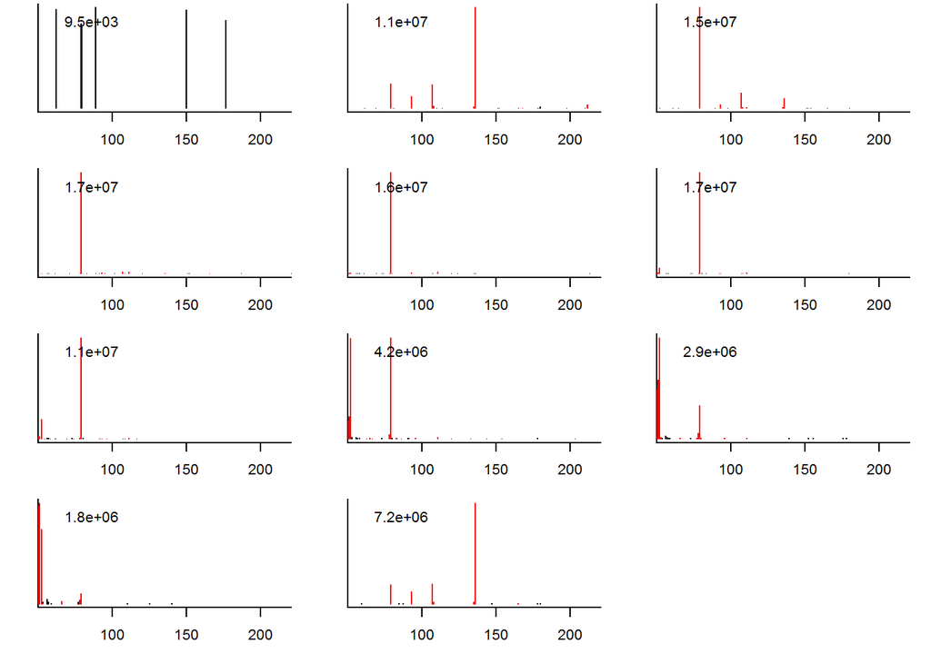

## 4132 Racecadotril

mz = 386.1421 (OK)

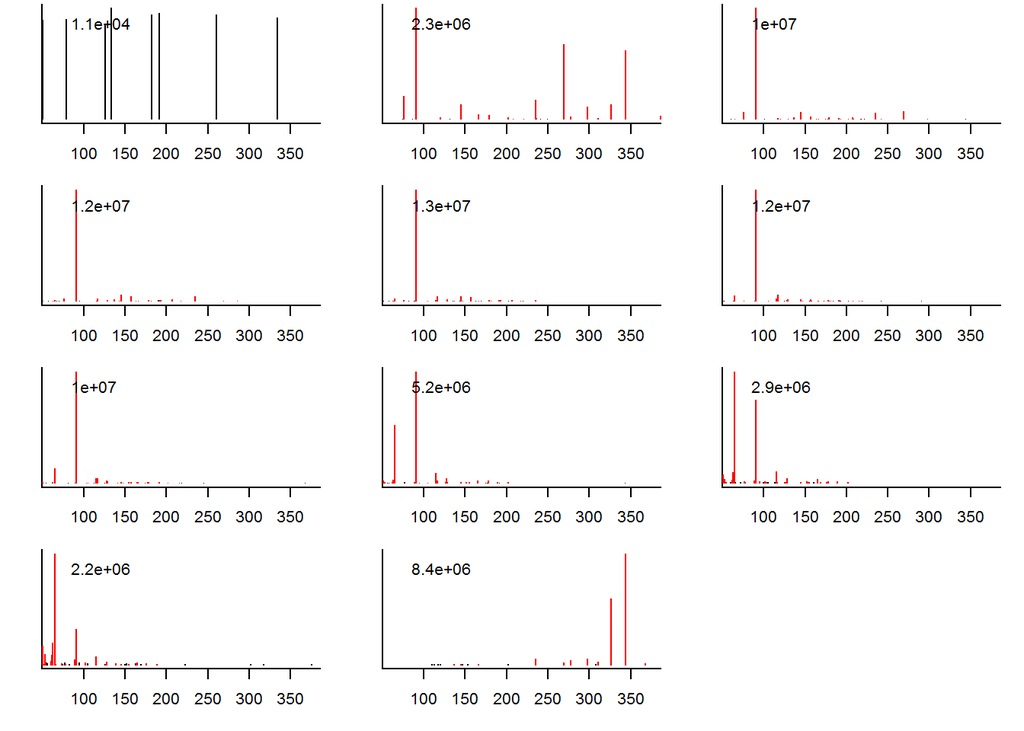

## 4138 Phentermine HCl

mz = 150.1277 (OK)

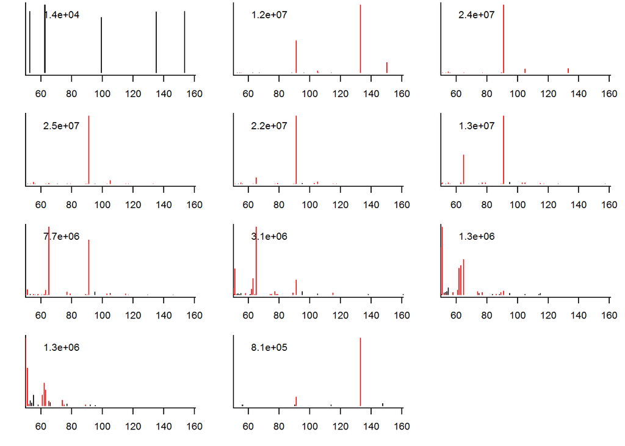

## 4126 Cromolyn disodium salt

mz = 469.0765 (OK)

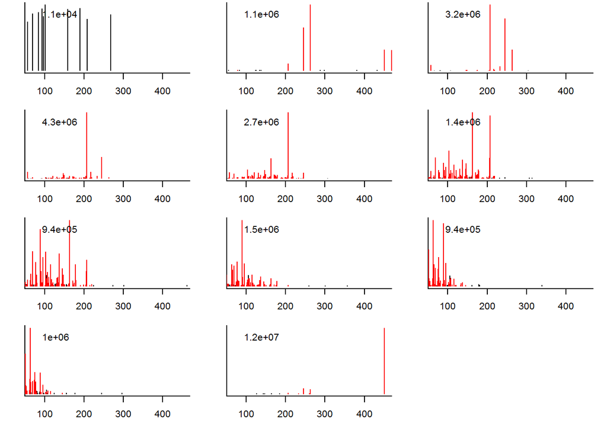

## 4183 Fluxapyroxad (BAS 700 F)-TP CSCD465008

mz = 163.0314 (OK)

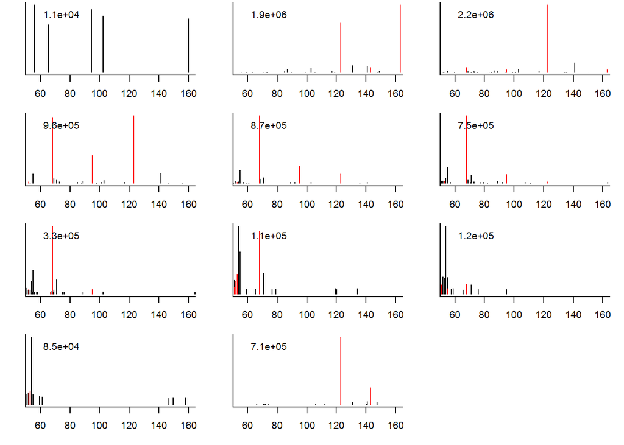

## 4184 Fluxapyroxad (BAS 700 F)-TP CSAA798670

mz = 177.047 (OK)

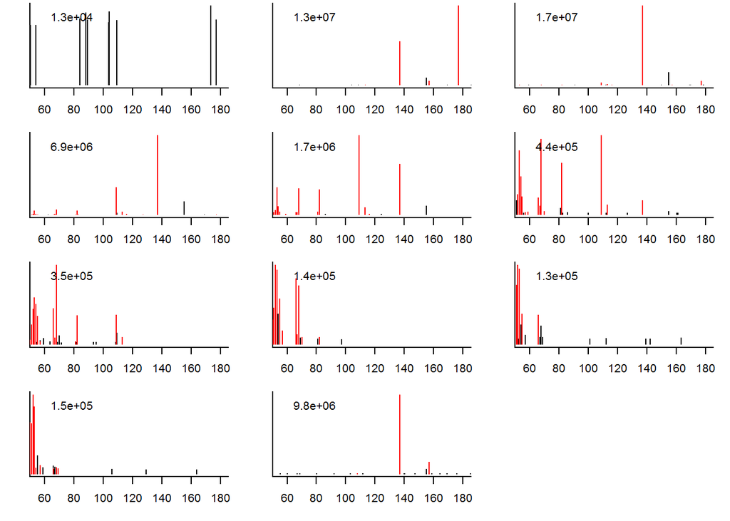

## 4171 Chlorothalonil-TP R471811

mz = 346.9058 (OK)

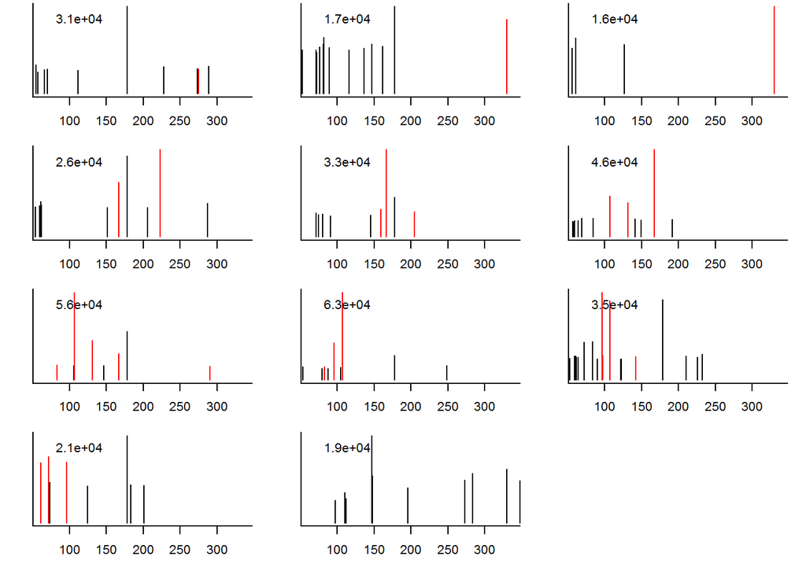

## 4114 R417888 (Chlorothalonil)

mz = 328.8952 (OK)

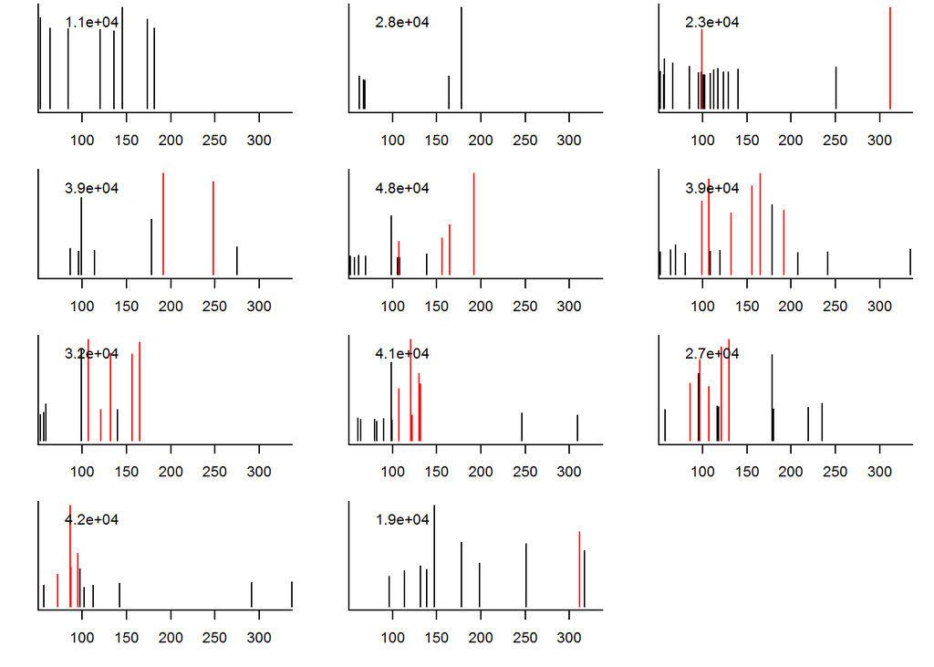

## 4172 Chlorothalonil-TP SYN507900

mz = 264.9333 (OK)

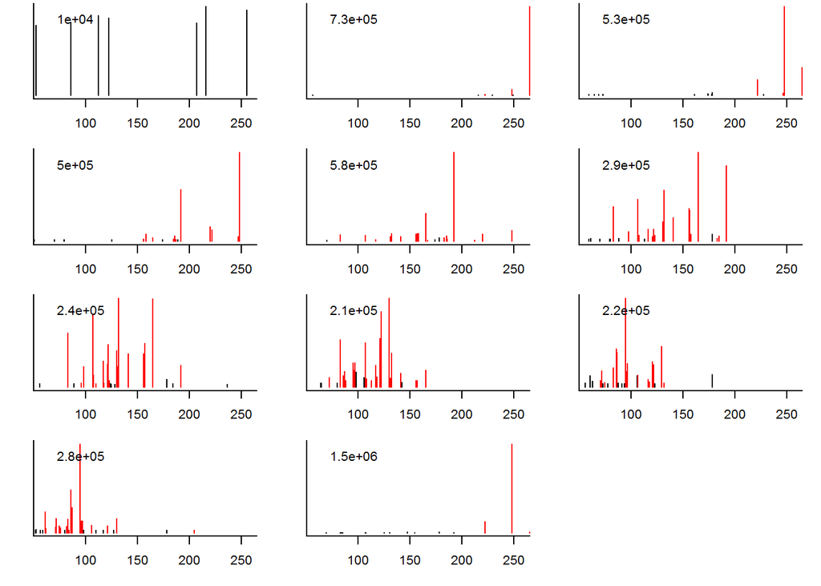

## 4182 Cycloxydim-TP BH 517-TSO E/Z-isomer

mz = 342.1734 (OK)

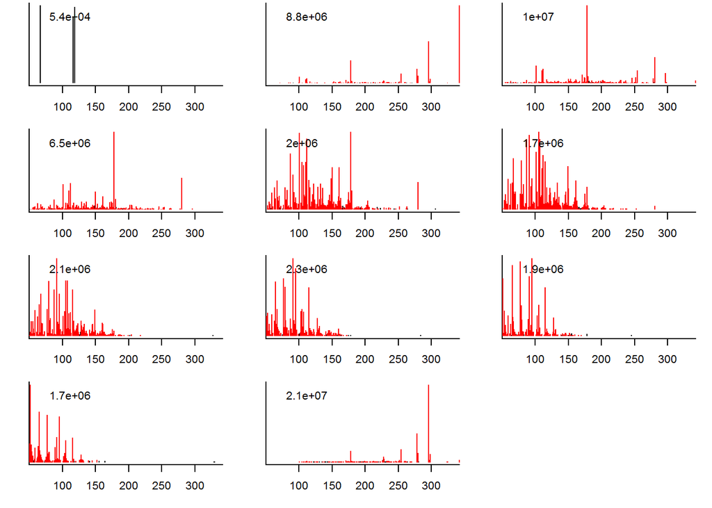

## 4173 Cyprodinil-TP CGA 249287

mz = 150.1026 (OK)

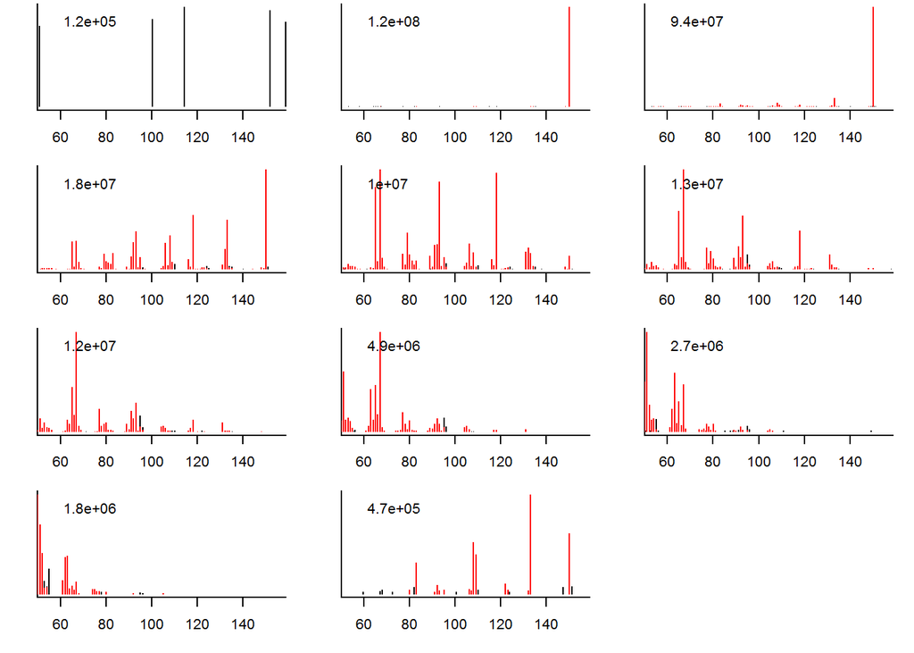

## 4174 Dimethachlor-TP CGA 369873

mz = 244.0638 (OK)

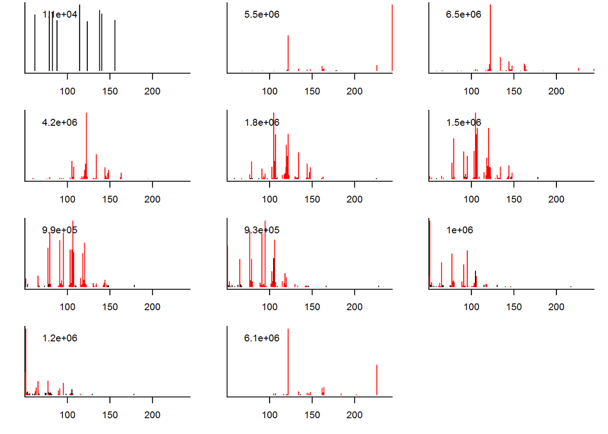

## 4181 Fipronil-TP RPA 200761

mz = 455.9406 (OK)

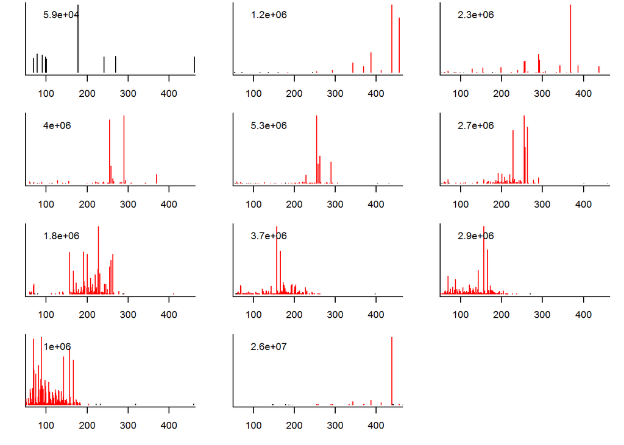

## 4170 Metalaxyl-M-TP CGA108906

mz = 296.1129 (OK)

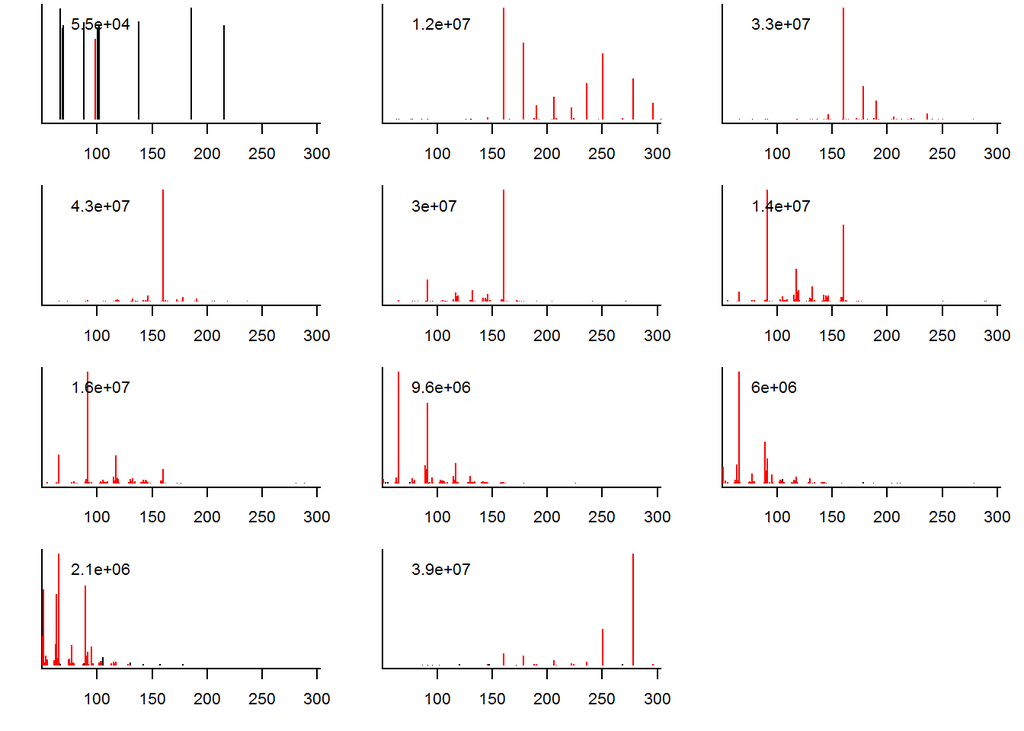

## 4178 Pinoxaden-TP NOA 407854

mz = 317.186 (OK)

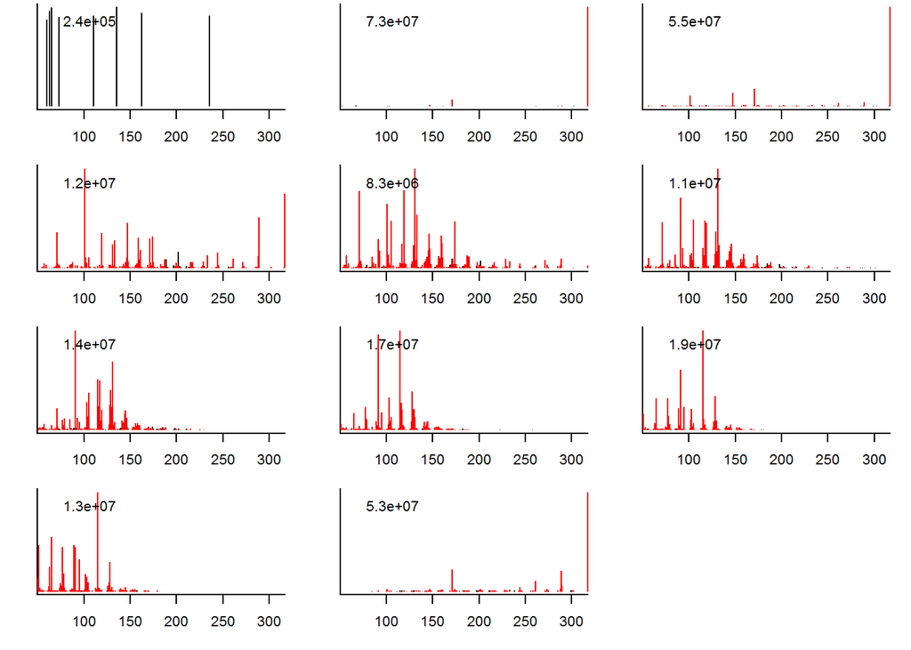

## 4168 Pymetrozine-TP CGA294849

mz = 143.0564 (OK)

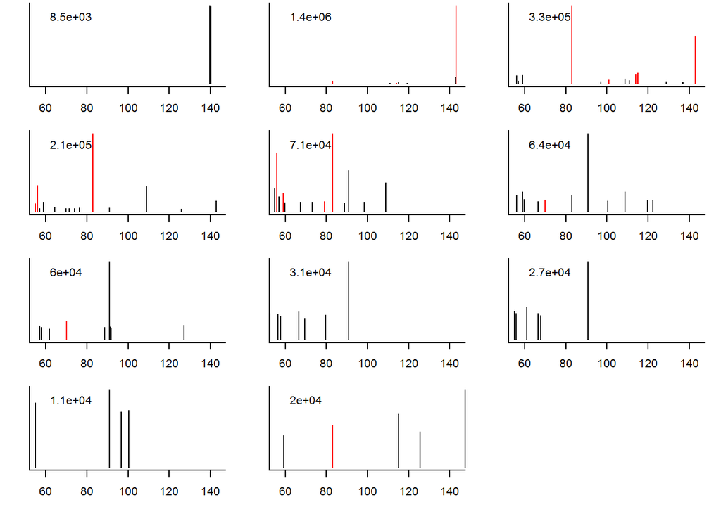

## 4169 Pymetrozine-TP CGA371075

mz = 142.0611 (OK)

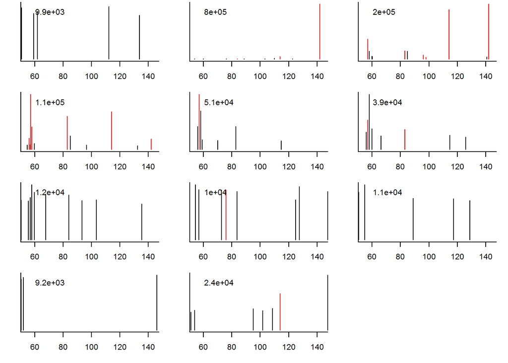

## 4175 Terbuthylazine-TP CSCD648241

mz = 199.119 (OK)

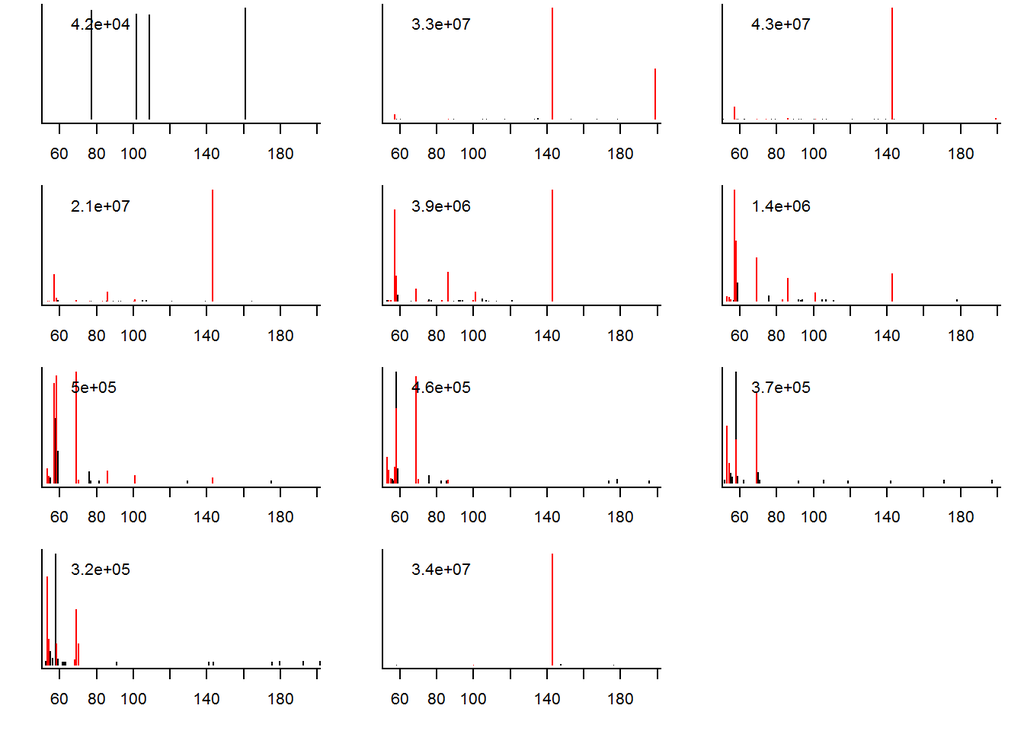

## 4187 Terbuthylazine-TP MT23_GS16984

mz = 185.1033 (OK)

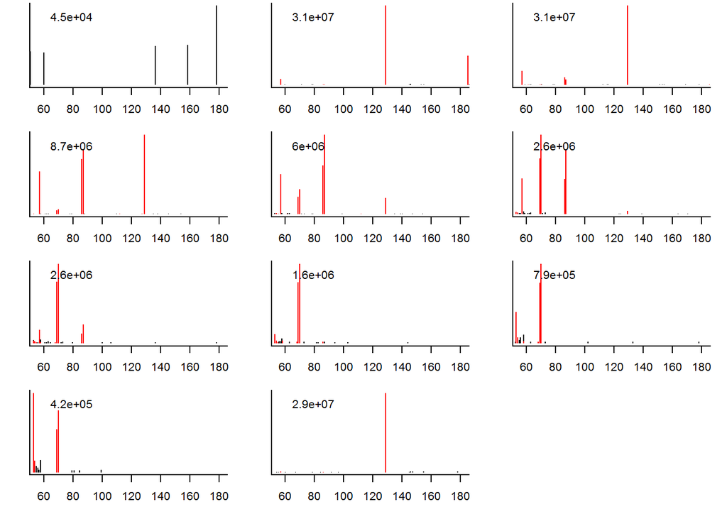

## 4177 Terbuthylazine-TP CSCD692760

mz = 199.0826 (OK)

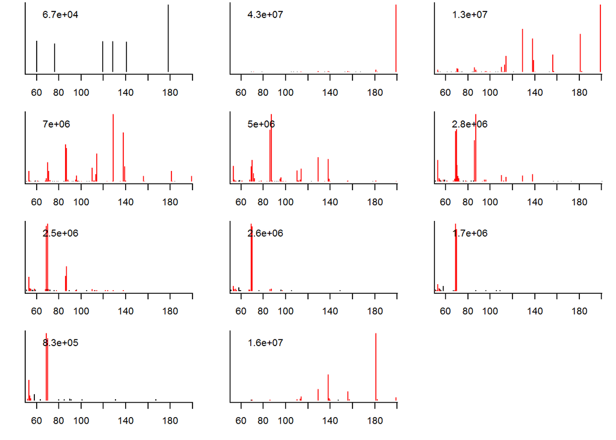

## 4176 Terbuthylazine-TP CSAA036479

mz = 214.0935 (OK)

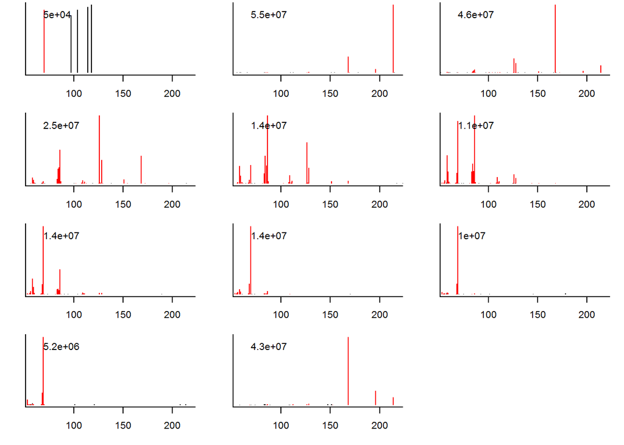

## 4186 Terbuthylazine-TP MT24_G35713

mz = 129.0407 (OK)

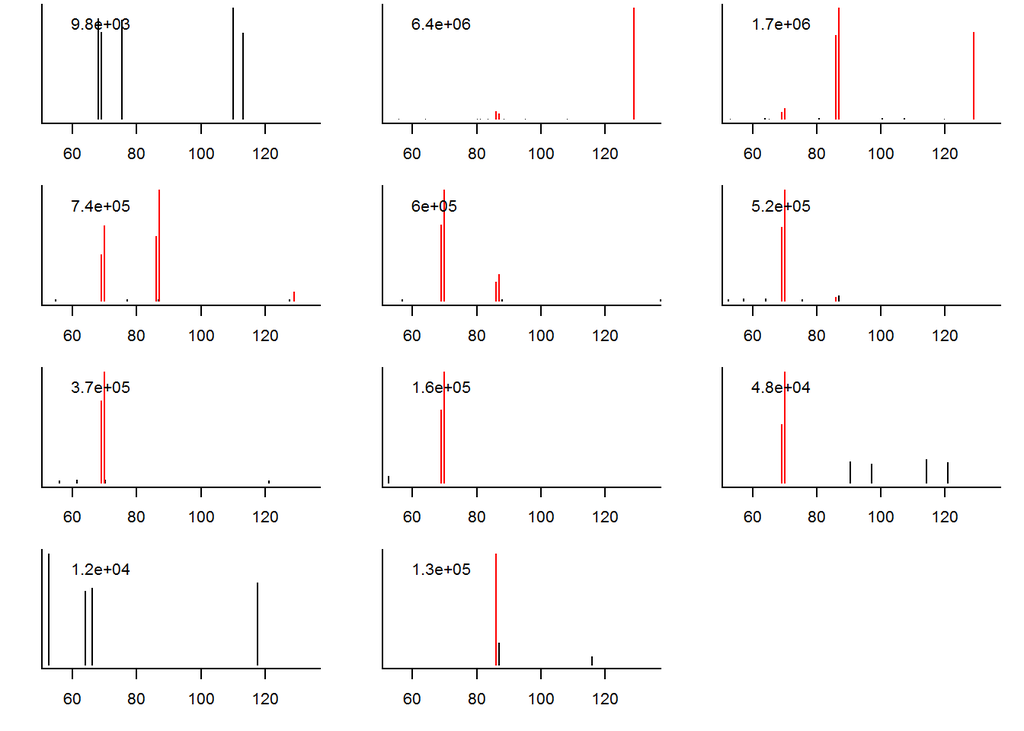

## 4180 Metolachlor-TP CGA 368208 (=Acetochlor sulfonic acid)

mz = 258.0795 (OK)

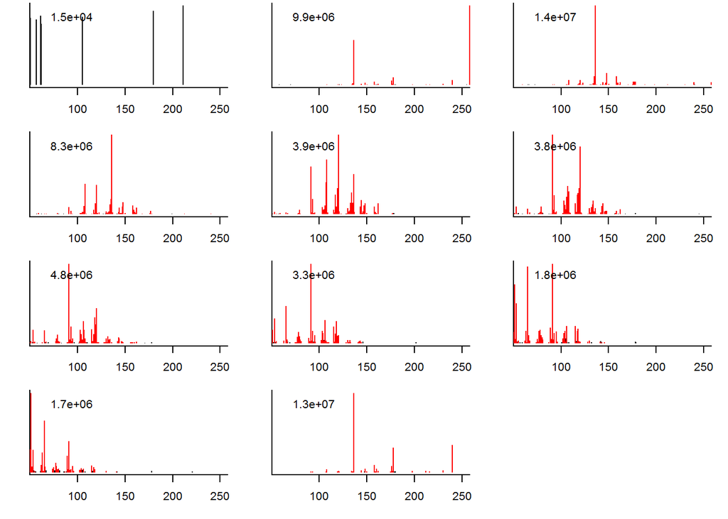

## 4179 Metolachlor-TP NOA 413173

mz = 330.1006 (OK)

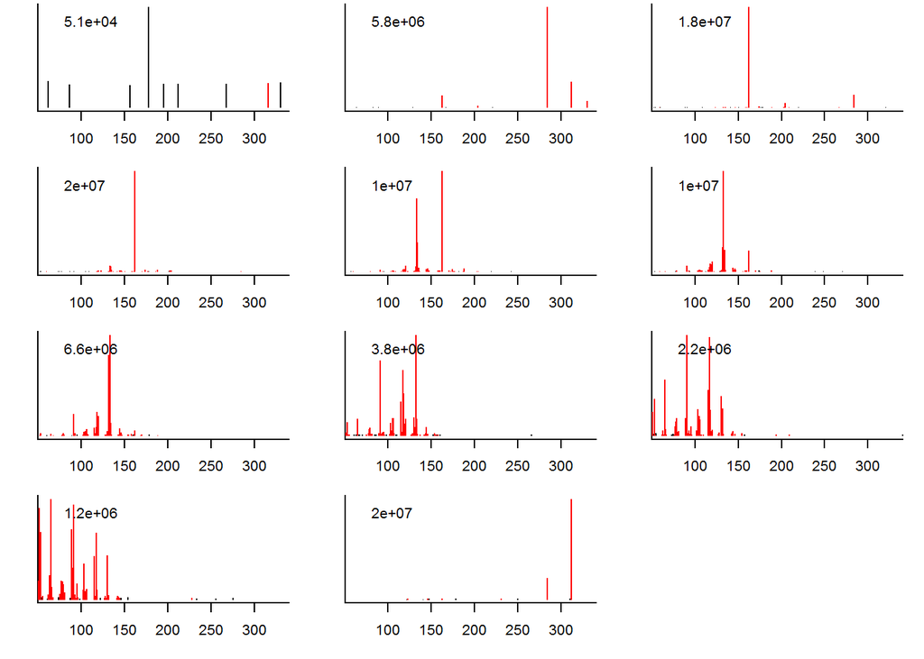

## 4195 Asulam-TP Sulfanilamide

mz = 173.0379 (OK)

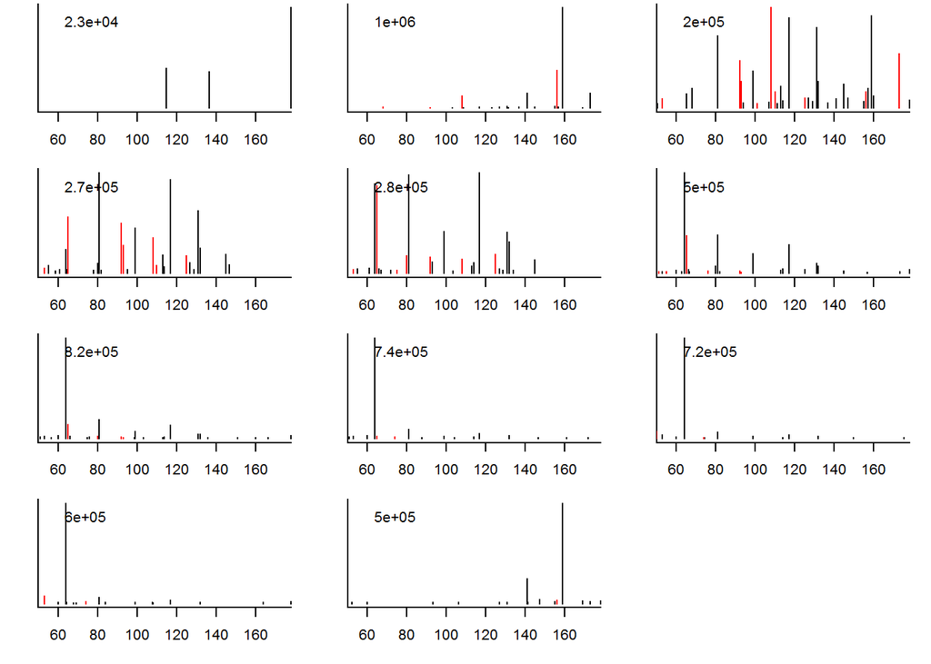

## 4196 Ethofumesate-2-hydroxy

mz = 259.0635 (OK)

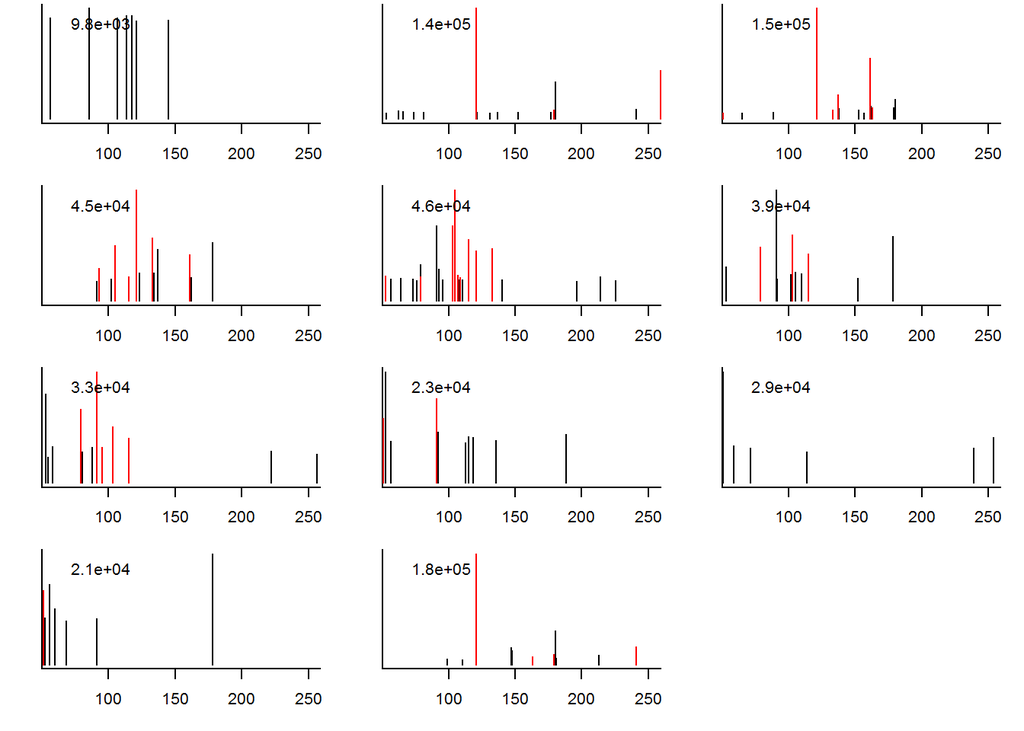

## 4197 Pirimicarb-desamido

mz = 168.1131 (OK)

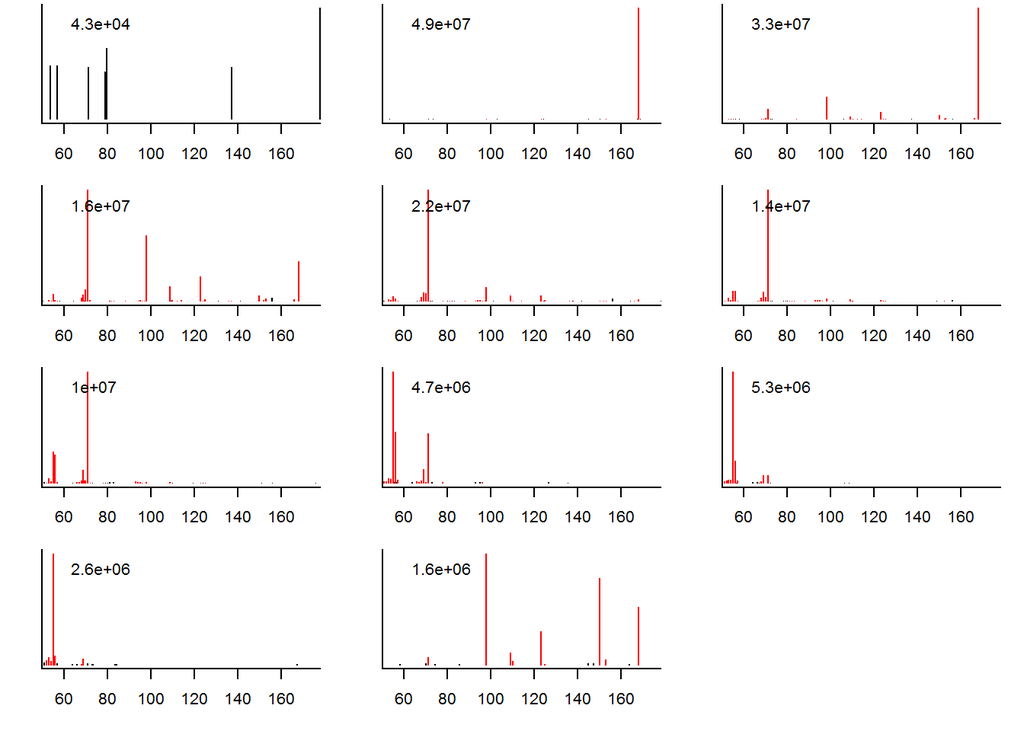

## 3534 Pyrifenox

mz = 295.0399 (OK)

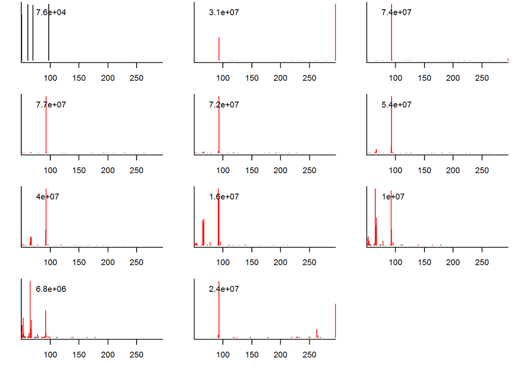

## 4084 2-Amino-4,6-dimethoxypyrimidine

mz = 156.0768 (OK)

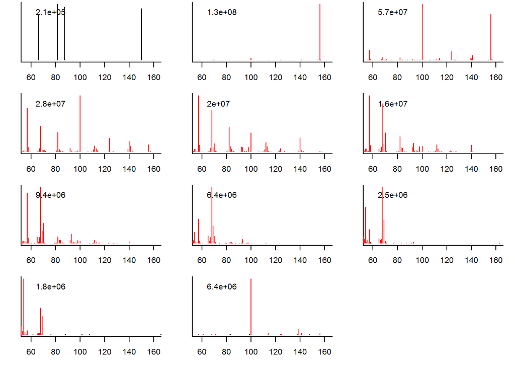

## 4086 endosulfan sulfat

mz = (not found)

## 3649 Aldicarb-sulfoxide

mz = 207.0798 (OK)

## 111 Chlorothalonil-4-hydroxy

mz = (not found)

## 4090 Isophthalonitrile

mz = (not found)

[figure not shown]